# Prediction Model

Karson Eilers

2023-12-03

# Setup and Configuration

```r
library(lubridate)
library(tidyverse)
library(ggplot2)
library(melt)
library(reshape2)
library(corrplot)
library(glmnet)
library(vars)
library(Metrics)
```

# Introduction & Business Problem

Maverik, an industry-leading fuel and convenience retailer, partnerered with students in the University of Utah Master of Science in Business Analytics (MSBA) Program to tackle a difficult business problem. As Maverik opens 30 new locations per year, they face the unique challenge of forecasting and evaluating first-year site performance. A more accurate model will enable cost-effective and accurate predictions for first-year sales, which in turn will improve Maverik’s financial planning and operations management.

This document explores the data sample provided by Maverik and utilizes a simple Vector AutoRegression (VAR) model to forecast total annual sales performance given two input timespans (14 days and 21 days). Models will be evaluated using Root Mean Square Error (RMSE).

# Exploratory Data Analysis

## Understanding Target Variables

Maverik provided two sets of data for modeling. The first file contained sales measures for four metrics across 38 stores. Each store has one year of sales observations (opening day sales + 365 subsequent days). Maverik requested forcasts for each of these variables:

- Unleaded gasoline
- Diesel fuel
- Food service
- Inside store merchandise

The second data file contains 53 qualitative predictor variables for 37/38 of the stores. The VAR model employed below only uses the four outcome variables, so the exploratory data analysis (EDA) will focus on those four. A few of the qualitative predictor variables will be used to check for significant store outliers that could disproportionately affect the store sales.

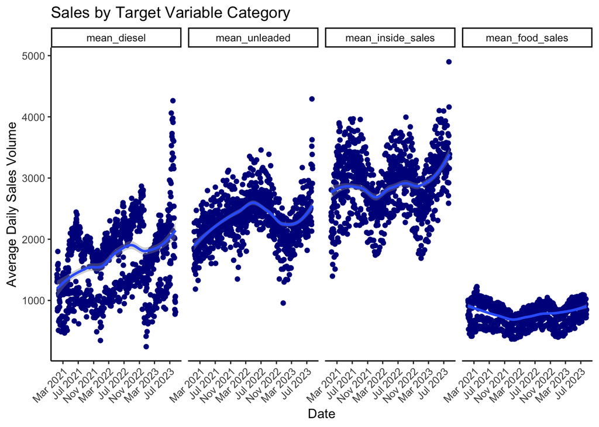

```r
#imports qualitative dataset
qual_data <- read.csv("qualitative_data_msba.csv")

#imports time series analysis dataset
raw_ts <- read.csv('time_series_data_msba.csv')

#imports a few key variables from qualitative data set
select_qual <- qual_data %>%
  dplyr::select(
    "site_id_msba",
    "square_feet",
    "parking_spaces",
    "lottery",
    "bonfire_grill",
    "pizza",
    "ethanol_free",
    "hi_flow_lanes",
    "rv_lanes",
    "def",
    "rv_dumps",
  )

#Creates a merged data set, by = site_id_msba by default
merged_df <- merge(raw_ts,select_qual)

#converting characters to factors and rename column that has a row identifier
merged_df <- merged_df %>%
  mutate(across(where(is.character),as.factor)) %>%
  rename("row_id" = "X")


#mean subset generates an average value for across stores for each given date
mean_subset <- raw_ts %>%
  dplyr::select('calendar.calendar_day_date',
         'diesel','unleaded',
         'daily_yoy_ndt.total_inside_sales',
         'daily_yoy_ndt.total_food_service') %>%
  rename('date' = 'calendar.calendar_day_date',
         'inside_sales' = 'daily_yoy_ndt.total_inside_sales',
         'food_sales' = 'daily_yoy_ndt.total_food_service'
         ) %>%
  group_by(date) %>%
   mutate(mean_diesel = mean(diesel),
          mean_unleaded = mean(unleaded),
          mean_inside_sales = mean(inside_sales),
          mean_food_sales = mean(food_sales)
          ) %>%
   dplyr::select('date','mean_diesel', 'mean_unleaded','mean_inside_sales','mean_food_sales') %>%
   unique()

#Lengthens the previous subset and converts target variable categories to types in a new field
lng_avg <- melt(mean_subset, id.vars="date",variable.name="product_type",value.name="average_sales")

# Convert 'date' column to date type
#lng_avg$date <- as.Date(lng_avg$date, format = "%m/%d/%Y")
lng_avg$date <- as.Date(lng_avg$date)


#Creates a faceted line plot by category
ggplot(lng_avg, aes(x=ymd(date), y=average_sales)) + geom_point(color="darkblue") + facet_grid(~product_type) + scale_x_date(date_labels="%b %Y",
               date_breaks = "4 month",
               guide = guide_axis(angle=45)) +
  labs(title="Sales by Target Variable Category", y = "Average Daily Sales Volume", x = "Date") + geom_smooth(method=loess) +
  theme_classic()
```

We will take a closer look at the data distributions. The values above display all the outcome variables along the same axis. This shows variation in trends, but the outcome variables are measured in different values (sales vs. dollars) so they should be plotted separately going forward.

The following two visuals show the density plots for the distributions of the four types of sales. Diesel and gasoline are measured by the same values (sales) and inside store merchandise sales and food service are measured the same way (dollars). The Diesel sales density distribution plot suggests that the high large average values are pulled up by an outlier store.

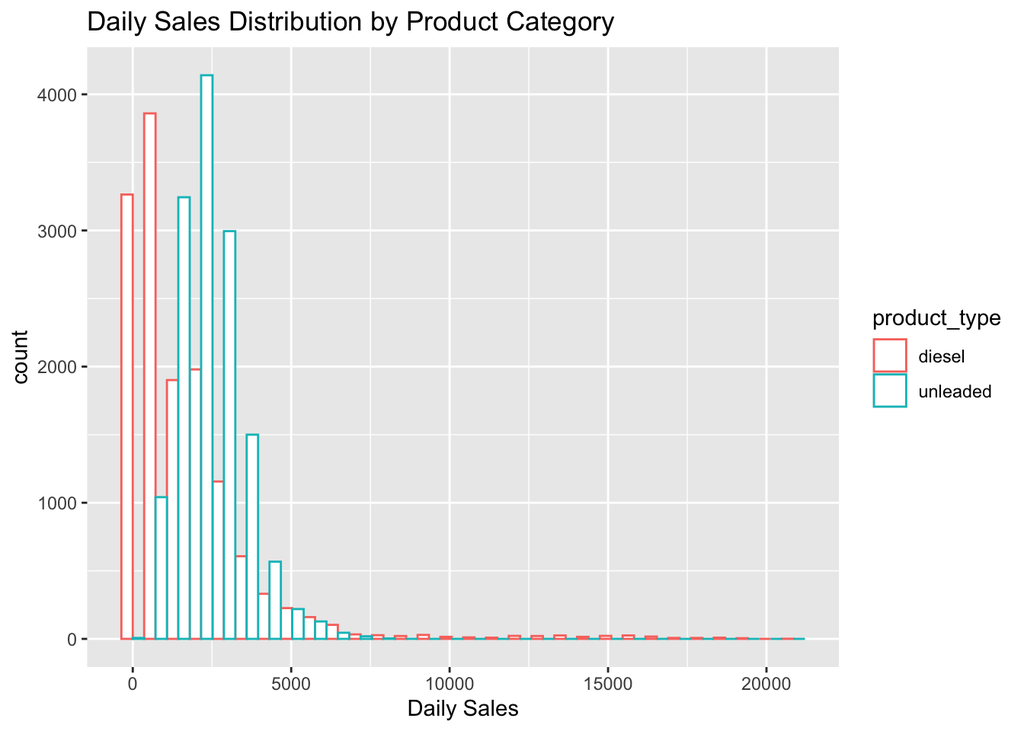

```r
#Data distribution for both types of fuel sales.
raw_ts %>%
  dplyr::select("diesel",
         "unleaded", ) %>%
  melt(variable.name = "product_type", value.name = "sales") %>%
  ggplot(aes(x=sales, color=product_type)) + geom_histogram(fill="white", position="dodge") + labs(title="Daily Sales Distribution by Product Category", x = "Daily Sales")
```

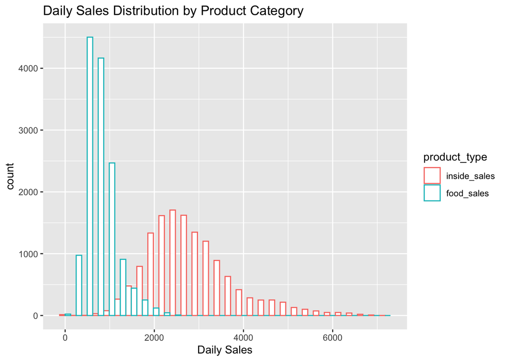

```r
#Data distribution for both types of inside store sales.
raw_ts %>%
  dplyr::select("daily_yoy_ndt.total_inside_sales",
         "daily_yoy_ndt.total_food_service") %>%
  rename('inside_sales' = 'daily_yoy_ndt.total_inside_sales',
         'food_sales' = 'daily_yoy_ndt.total_food_service'
         ) %>%
  melt(variable.name = "product_type", value.name = "sales") %>%
  ggplot(aes(x=sales, color=product_type)) + geom_histogram(fill="white", position="dodge") + labs(title="Daily Sales Distribution by Product Category", x = "Daily Sales")
```

## Qualitative Variables

Next, we will explore some of the structureal parameters of the stores to see whether there are reasons a store sales might be significantly different from the others (e.g., if one store’s footprint was twice as large as the others).

```r
# Summarizes store layout values
qual_data %>%
  dplyr::select("square_feet",
         "parking_spaces",
         "lottery"
         ) %>%
  mutate(lottery = as.factor(lottery)) %>%
  summary()
```

```
##   square_feet   parking_spaces  lottery
##  Min.   :2933   Min.   :23.00   No :14
##  1st Qu.:5046   1st Qu.:34.00   Yes:23
##  Median :5046   Median :38.00
##  Mean   :4970   Mean   :37.41
##  3rd Qu.:5046   3rd Qu.:41.00
##  Max.   :6134   Max.   :49.00
```

```r
# Summarizes qual data food variables
qual_data %>%
  dplyr::select("freal",
         "bonfire_grill",
         "pizza",
         "cinnabon",
         "godfather_s_pizza"
         ) %>%
  mutate_all(as.factor) %>%
  summary()
```

```
##  freal    bonfire_grill pizza    cinnabon godfather_s_pizza
##  No : 1   No :11        No :22   No :35   No:37
##  Yes:36   Yes:26        Yes:15   Yes: 2
```

```r
# Summarizes qual data related to fuel stations
qual_data %>%
  dplyr::select("ethanol_free",
         "diesel",
         "hi_flow_lanes",
         "rv_lanes",
         "hi_flow_rv_lanes"
         ) %>%
  mutate_all(as.factor) %>%
  summary()
```

```
##  ethanol_free diesel   hi_flow_lanes rv_lanes hi_flow_rv_lanes
##  No :11       Yes:37   No :15        No :14   No :15
##  Yes:26                Yes:22        Yes:23   Yes:22
```

```r
# Summarizes qual data related to fuel stations
qual_data %>%
  dplyr::select("def",
         "cat_scales",
         "car_wash",
         "ev_charging",
         "rv_dumps",
         "propane"
         ) %>%
  mutate_all(as.factor) %>%
  summary()
```

```
##   def     cat_scales car_wash ev_charging rv_dumps propane
##  No :14   No :32     No:37    No:37       No :24   No : 6
##  Yes:23   Yes: 5                          Yes:13   Yes:31
```

There do not appear to be any structural reasons that the outcome variables for some stores would be significantly different than others. The data does not include key factors like the the stores’ geographic locations or proximity to major transportation corridor.

Now that we have a better sense of the data, we will proceed to the modeling step.

# Modeling

## Partitioning

The first step in modeling is to select the variables we need and partition the data into a train and test set. We have 38 total stores, 80% of which need to be assigned to the training set and 20% into a test set. We do this by selecting unique store IDs and assigning them randomly. This results in a 30-store training set and an 8-store testing set. The purpose behind training and testing is so we can verify how the model performs when it is introduced to new data.

Now that we the data partitioned, we convert both the training and testing sets to time series variables indexed for each store on the number of days open (e.g., day 0 through day 365). Next, the model is trained.

The VAR model is multivariate time series which allows us to measure how multiple endogenous variables change together over time. It does this by regressing each of the endogenous variables against 1 specified lag of the other variables. In this case, the model uses a one-day lag. In other words, the model captures the aggregate effect of the prior day outcome variables. The VAR model can utilize exogenous predictor variables as well, so why were the qualitative variables excluded from the model? There are two reasons for this decision:

- First, not all predictor variables are meaningfully related to each of the respective outcome variables. VAR does not allow us to individually select the features that matter for a given model.
- Second, Maverik operates stores in a variety of regions and even states throughout the Intermountain West. Varying climates and regulatory regimes could significantly impact a fine-tuned model’s predictive ability. For example, if Maverik opened a store in southern California, the store would likely be less influenced by seasonality than a store in a mountainous community in Utah. A Maverik in California could also sell a wider variety of products (e.g., wine, liquour, lottery tickets) and a store in Utah cannot. This could have a distortionary effect on merchandise sales if the training set only included Utah stores and the model would perform poorly when applied elsewhere. This model functions on any store that sells unleaded gasoline, diesel, food service, and store merchandise.

```r
#Converts train and test sets to time series values
train_ts <- ts(train_set, start=1, frequency=1)
test_ts <- ts(test_set, start=1, frequency=1)

#Trains the VAR model on the training dataset using only endogenous values and a 1-day lag
var_model <- VAR(train_ts, p=1)

#Summarizes the model coefficients
#Summary supressed for readability
#summary(var_model)
```

Now that we have the model trained, it’s time to use it to calculate predictions. For Maverik’s specific purposes, the model needs to be flexible enough to predict on any given timespan between 1 and 365. To do this, we write two custom functions instead using a pre-build package like Caret. The first function creats a prediction for a given day. The second function uses the first to aggregate the predictions. This function can also take any given VAR model that meets the same parameters, so the same code could be deployed on a training set that spans multiple years.

```r
#Creates two methods to calculate predicted values based on model values

#Var_predict (VAR prediction method) to calculate sales values
  ## model = model selection
  ## last_obs = last observed values (ordered by 1: food service; 2: inside sales; 3: diesel; 4: unleaded)
  ## type = target prediction

var_predict <- function(model, last_obs) {
    #Calculates food service sales
    fs <- model$varresult$daily_food_service$coefficients[[1]]*last_obs[1]
    is <- model$varresult$daily_food_service$coefficients[[2]]*last_obs[2]
    ds <- model$varresult$daily_food_service$coefficients[[3]]*last_obs[3]
    du <- model$varresult$daily_food_service$coefficients[[4]]*last_obs[4]
    intercept <- model$varresult$daily_food_service$coefficients[[5]]
    food_service_pred <- fs + is + ds + du + intercept
    #Calculates inside sales
    fs <- model$varresult$daily_inside_sales$coefficients[[1]]*last_obs[1]
    is <- model$varresult$daily_inside_sales$coefficients[[2]]*last_obs[2]
    ds <- model$varresult$daily_inside_sales$coefficients[[3]]*last_obs[3]
    du <- model$varresult$daily_inside_sales$coefficients[[4]]*last_obs[4]
    intercept <- model$varresult$daily_inside_sales$coefficients[[5]]
    inside_sales_pred <- fs + is + ds + du + intercept
    #Calculates diesel sales
    fs <- model$varresult$daily_diesel$coefficients[[1]]*last_obs[1]
    is <- model$varresult$daily_diesel$coefficients[[2]]*last_obs[2]
    ds <- model$varresult$daily_diesel$coefficients[[3]]*last_obs[3]
    du <- model$varresult$daily_diesel$coefficients[[4]]*last_obs[4]
    intercept <- model$varresult$daily_diesel$coefficients[[5]]
    diesel_pred <- fs + is + ds + du + intercept
    #Calculates Unleaded Gasoline sales
    fs <- model$varresult$daily_unleaded$coefficients[[1]]*last_obs[1]
    is <- model$varresult$daily_unleaded$coefficients[[2]]*last_obs[2]
    ds <- model$varresult$daily_unleaded$coefficients[[3]]*last_obs[3]
    du <- model$varresult$daily_unleaded$coefficients[[4]]*last_obs[4]
    intercept <- model$varresult$daily_unleaded$coefficients[[5]]
    unleaded_pred <- fs + is + ds + du + intercept
    return(c(food_service_pred, inside_sales_pred, diesel_pred, unleaded_pred))
}

#Method VAR forecast utilized var_predict to form aggregate forecasts
  ##model_input = model to pass through to var_predict
  ##start_vals = the most recent day's observation, takes a vector or list of four numbers
  ##num_days = the number of days to forecast
var_forecast <- function(model_input, start_vals, num_days) {
  #creates a new data set to store values and return
  new_df <- data.frame(food_service = start_vals[1],
                       inside_sales = start_vals[2],
                       diesel_sales = start_vals[3],
                       unleaded_sales = start_vals[4]
                       )
  #stores baseline (day n) prediction in the dataframe
  new_pred <- var_predict(model=model_input, last_obs=as.numeric(new_df[1,1:4]))
    temp_df <- data.frame(food_service = new_pred[1],
                       inside_sales = new_pred[2],
                       diesel_sales = new_pred[3],
                       unleaded_sales = new_pred[4])
    new_df <- rbind(new_df, temp_df)

  #iterates through length of days specified making predictions on 1-day prior observations
  for (i in 2:num_days) {
    new_pred <- var_predict(model=model_input, last_obs=as.numeric(new_df[i-1,1:4]))
    temp_df <- data.frame(food_service = new_pred[1],
                       inside_sales = new_pred[2],
                       diesel_sales = new_pred[3],
                       unleaded_sales = new_pred[4])
    #attaches day n predictions to datagrame
    new_df <- rbind(new_df, temp_df)
  }
  #returns the new df with predictions
  return(new_df)
}
```

# Results

The training and testing set dataframes were modified in the modeling stages, so they are reset. The calculate performance we need another function that can plug in the previous prediction function and calculate the root mean square error (RMSE) over the course of a year compared to the actual events in the test set. The RMSE calculator also need to be able to vary in time span.

```r
set.seed(123)

#Resets training sites
train_sites <- slice_sample(distinct_sites, n=30, replace=FALSE)

#constructs the train & test sets based on sampled ids
train_set <- filter(ts_data, site_id_msba %in% train_sites$site_id_msba)
test_set <- filter(ts_data, !site_id_msba %in% train_sites$site_id_msba)

#Wrapper for predictions
test_set_IDs <- test_set %>%
  distinct(site_id_msba)

#Creates a new function to calculate the total annual RMSE from the VAR predictions for any given start day, up to 1 year.
##start_day is the initial day to make the predictions from
##site_ids are the sites to apply from
##test data is the test_set with the actual values to base initial predictions (e.g., day 0, 14, 21) on and compare against
calc_rmse <- function(start_day, site_ids, test_data) {

  #each vector stores either predictions or actuals from the provided input data
  site_id_index <- c()
  diesel_predictions <- c()
  actual_diesel <- c()
  unleaded_predictions <- c()
  actual_unleaded <- c()
  inside_store_predictions <- c()
  actual_inside_store <- c()
  food_service_predictions <- c()
  actual_food_service <- c()

  #for loop iterates through each site and makes predictions on it for the provided number of days
  for (i in as.vector(site_ids$site_id_msba)) {
    site <- i
    tempDF <- test_data %>%
      filter(site_id_msba == site) %>%
      dplyr::select(-site_id_msba) %>%
      arrange(Days_Since_Open)

    #predictions are stored in a temporary df
    tempDF <- tempDF %>% rename(
      "food_service" = "daily_yoy_ndt.total_food_service",
      "inside_sales" = "daily_yoy_ndt.total_inside_sales",
      "diesel_sales" = "diesel",
      "unleaded_sales" = "unleaded"
    )

    tempDF <- tempDF %>%
      dplyr::select(-Days_Since_Open)

    #forecast model applied here to the specific testing sites and number of days
    test_preds <- var_forecast(var_model, as.numeric(tempDF[(start_day+1), 1:4]), (365-(start_day)))

    #adds the remaining not predicted days (e.g, day 0, days 0-14, days 0-21) to the predictions
    test_preds <- dplyr::bind_rows(test_preds, tempDF[1:(start_day-1),])

    #stores annual sum predictions by outcome variable
    unleaded_sum <- sum(test_preds[,4])
    diesel_sum <- sum(test_preds[,3])
    inside_sales_sum <- sum(test_preds[,2])
    food_service_sum <- sum(test_preds[,1])

    #stores annual sum actual values by outcome variable
    actual_unleaded_sum <- sum(tempDF[,4])
    actual_diesel_sum <- sum(tempDF[,3])
    actual_inside_sales_sum <- sum(tempDF[,2])
    actual_food_service_sum <- sum(tempDF[,1])

    #indexes by site id
    site_id_index <- append(site_id_index, site)

    #adds new values the predicted or actual diesel series
    diesel_predictions <- append(diesel_predictions, diesel_sum)
    actual_diesel <- append(actual_diesel, actual_diesel_sum)

    #adds new values the predicted or actual unleaded series
    unleaded_predictions <- append(unleaded_predictions, unleaded_sum)
    actual_unleaded <- append(actual_unleaded, actual_unleaded_sum)

    #adds new values the predicted or actual merchandise series
    inside_store_predictions <- append(inside_store_predictions, inside_sales_sum)
    actual_inside_store <- append(actual_inside_store, actual_inside_sales_sum)

    #adds new values to the predicted or actual food service series
    food_service_predictions <- append(food_service_predictions, food_service_sum)
    actual_food_service <- append(actual_food_service, actual_food_service_sum)
  }


  #comine reults into a single dataframe
  resultsDF <- data.frame(cbind(site_id_index,
                                food_service_predictions,
                                actual_food_service,
                                inside_store_predictions,
                                actual_inside_store,
                                diesel_predictions,
                                actual_diesel,
                                unleaded_predictions,
                                actual_unleaded
                                ))

  #returns the aggregated DF
  return(resultsDF)

}
```

The baseline metrics given for Maverik’s current model were provided for a two- and three-week input time span, meaning the model estimates annual performance based on 14 days and 21 days of input data, respectively.

```r
#predicts annual sales based on two weeks of data for each store in the test set
preds2WK <- calc_rmse(14, test_set_IDs, test_set)

#predicts annual sales based on three weeks of data for each store in the test set
preds3WK <- calc_rmse(21, test_set_IDs, test_set)

#the following outputs calculate aggregate RMSE for each outcome variable in both time horizons
paste("unleaded 2wk:", rmse(preds2WK$actual_unleaded, preds2WK$unleaded_predictions))
```

```
## [1] "unleaded 2wk: 198680.644071404"
```

```r
paste("unleaded 3wk: ", rmse(preds3WK$actual_unleaded, preds3WK$unleaded_predictions))
```

```
## [1] "unleaded 3wk:  202672.325281005"
```

```r
paste("diesel 2wk: ", rmse(preds2WK$actual_diesel, preds2WK$diesel_predictions))
```

```
## [1] "diesel 2wk:  1309861.39145199"
```

```r
paste("diesel 3wk: ", rmse(preds3WK$actual_diesel, preds3WK$diesel_predictions))
```

```
## [1] "diesel 3wk:  1288705.56236797"
```

```r
paste("food service 2wk: ", rmse(preds2WK$actual_food_service, preds2WK$food_service_predictions))
```

```
## [1] "food service 2wk:  115923.481621002"
```

```r
paste("food service 3wk: ", rmse(preds3WK$actual_food_service, preds3WK$food_service_predictions))
```

```
## [1] "food service 3wk:  110660.84112709"
```

```r
paste("inside store sales 2wk: ", rmse(preds2WK$actual_inside_store, preds2WK$inside_store_predictions))
```

```
## [1] "inside store sales 2wk:  306819.884614594"
```

```r
paste("inside store sales 3wk: ", rmse(preds3WK$actual_inside_store, preds3WK$inside_store_predictions))
```

```
## [1] "inside store sales 3wk:  291722.514902151"
```

## Perfomance Table (RMSE)

| Category | Unleaded | Diesel | Food service | Inside store sales |
| --- | --- | --- | --- | --- |
| VAR 2 week | 198,681 | 1,309,861 | 115,924 | 306,820 |
| Baseline 2 week | 302,827 | 558,546 | 68,860 | 268,521 |
| VAR 3 week | 202,672 | 1,288,706 | 110,661 | 291,723 |
| Baseline 3 week | 259,909 | 482,976 | 66,252 | 243,858 |

## Model Performance Visualizations

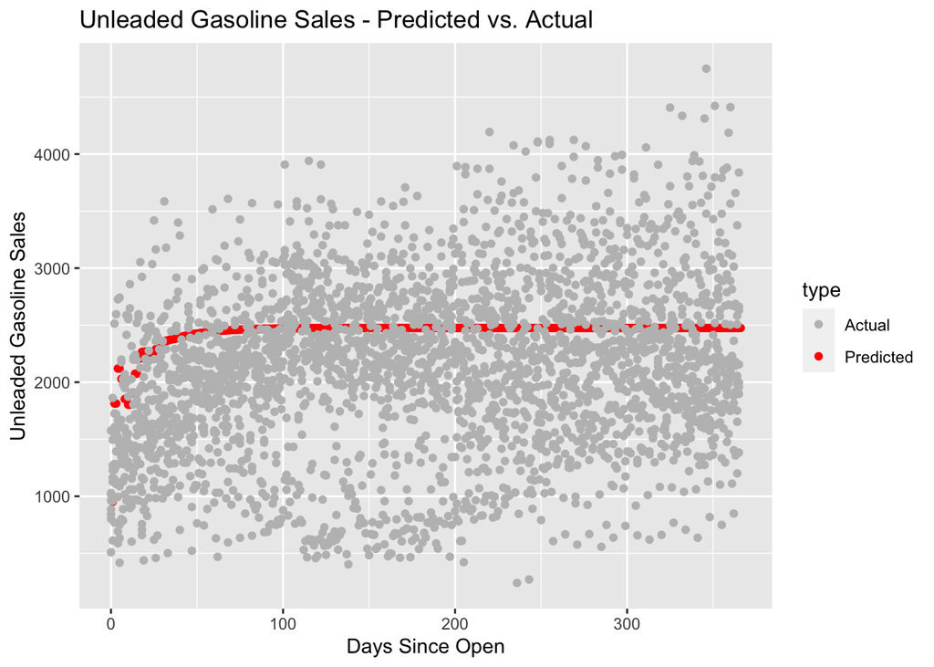

```r
test_set <- filter(ts_data, !site_id_msba %in% train_sites$site_id_msba)

#creates a simulated store based on average 'day 0' values from the test set to make predictions for
test_avg <- test_set %>%
  filter(test_set$Days_Since_Open == 0) %>%
  colMeans()

#new df stores predictions from the VAR forcast
preds_avg <- var_forecast(var_model, test_avg[2:5], 365)

#resets df index
row.names(preds_avg) <- NULL

#incorporates the days_since_open for the predicted values
preds_avg$Days_Since_Open <- 1:nrow(preds_avg)

#creates new field to distinguish predicted values from actual in the merge
preds_avg$type <- "Predicted"
test_set$type <- "Actual"

#drops site id from the dataset prior to the merge
test_set <- test_set %>%
  dplyr::select(-"site_id_msba")

#renames test_set features to match prediction feature names
test_set <- test_set %>%
  rename("food_service" = "daily_yoy_ndt.total_food_service",
         "inside_sales" = "daily_yoy_ndt.total_inside_sales",
         "diesel_sales" = "diesel",
         "unleaded_sales" = "unleaded"
         )
#reorders columns to match features for merge
preds_avg <- preds_avg[, c("Days_Since_Open", "food_service", "inside_sales", "diesel_sales", "unleaded_sales", "type")]

#merges predictions and actual observations
test_set <- rbind(preds_avg, test_set)

#Unleaded Plot
ggplot(data=test_set, aes(x=Days_Since_Open, y=unleaded_sales, color=type)) + geom_point() + xlab("Days Since Open") + ylab("Unleaded Gasoline Sales") + scale_color_manual(values=c("grey","red")) + ggtitle("Unleaded Gasoline Sales - Predicted vs. Actual")
```

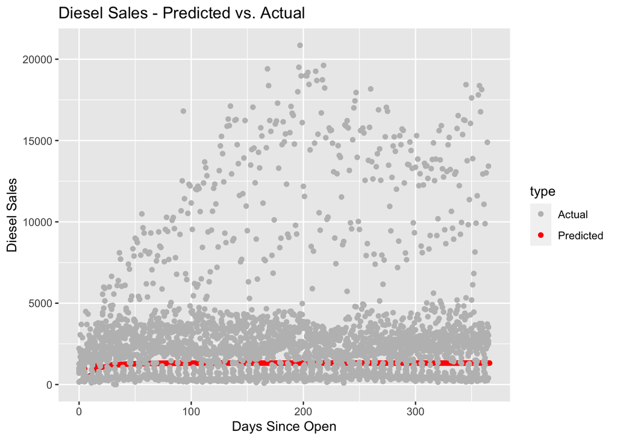

```r
#Diesel Plot
ggplot(data=test_set, aes(x=Days_Since_Open, y=diesel_sales, color=type)) + geom_point() + xlab("Days Since Open") + ylab("Diesel Sales") + scale_color_manual(values=c("grey","red")) + ggtitle("Diesel Sales - Predicted vs. Actual")
```

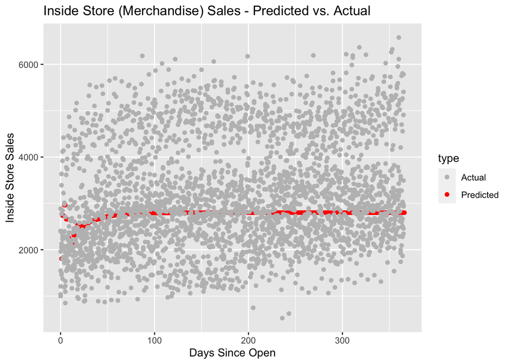

```r
#Inside Sales Plot
ggplot(data=test_set, aes(x=Days_Since_Open, y=inside_sales, color=type)) + geom_point() + xlab("Days Since Open") + ylab("Inside Store Sales") + scale_color_manual(values=c("grey","red")) + ggtitle("Inside Store (Merchandise) Sales - Predicted vs. Actual")
```

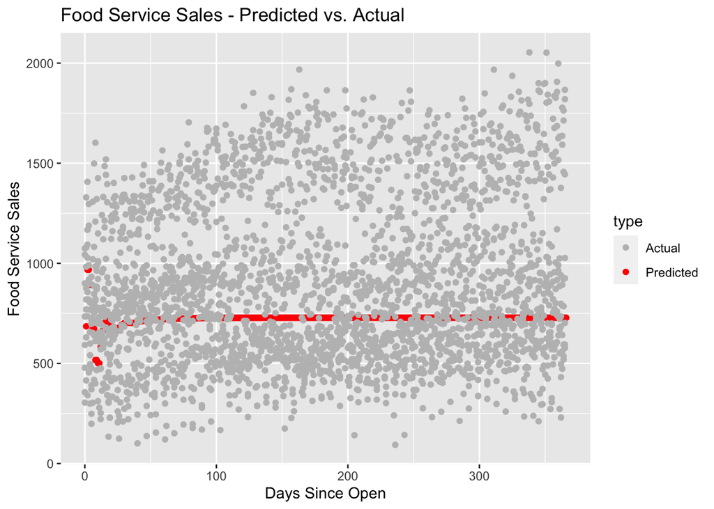

```r
#Food Service Plot
ggplot(data=test_set, aes(x=Days_Since_Open, y=food_service, color=type)) + geom_point() + xlab("Days Since Open") + ylab("Food Service Sales") + scale_color_manual(values=c("grey","red")) + ggtitle("Food Service Sales - Predicted vs. Actual")
```

## Conclusions

The visuals above show some similarity in how the four models function; namely that there is some volatility in the initial days as the stores become established. Over time, though, the models show that the store values stabilize and approach the central tendency in the data. It is intuitive that the models tend to predict well in the aggregate - as days increase store performance balances out. The diesel sales plot also shows why that particular metric has such a high RMSE. The plot indicates that one store provides significant variance. So, while the model is similar to *most* of the data, one store introduces enough variance to drive a much higher standard error. A better RMSE could likely be achieved by excluding that one outlying store, however, it is important that the model can encounter outlying stores. The model will likly improve as it is trained on more data which includes outlying stores so it can better account for them.